# Anotação e Ruído de Rótulos

Prof. Cesar Henrique Comin

## Rótulos de imagens

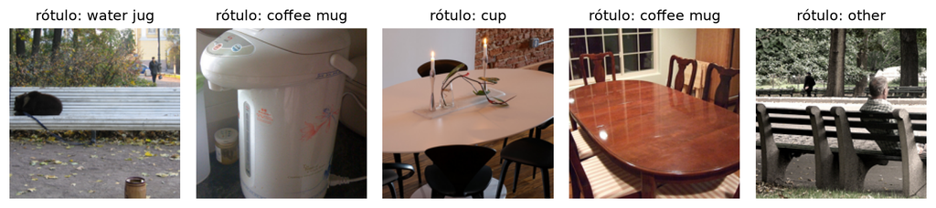

- Um rótulo é o resultado de uma análise feita por uma pessoa, e pode conter erros.
- No `pvd_images`, cerca de **12%** dos rótulos estão errados. Taxas dessa ordem são comuns em datasets reais.
- A análise de rotulação é comum em classificação, detecção, segmentação e outras tarefas em imagens. Para simplificar, vamos falar apenas de **classificação**.

## De onde vem o erro

- **Classes ambíguas**: onde termina uma caneca e começa uma xícara?
- **Imagem difícil**: escura, desfocada, objeto pequeno ou parcialmente visível.
- **Anotador**: pressa, cansaço, falta de treinamento, interpretação própria das classes.
- **Protocolo vago**: a pessoa não sabe o que fazer com um caso que as instruções não cobrem.
- Os dois primeiros são propriedades dos dados. Os dois últimos são propriedades do **processo de anotação**.

# Protocolos de anotação

## O que um protocolo define

- **Definição das classes**, com exemplos e contraexemplos em imagens.
- **Regras para casos de borda**: dois objetos na mesma foto, objeto cortado, foto de um desenho.
- Uma classe de escape, como `other` ou “não sei”. Sem ela o anotador é obrigado a chutar.
- **Quantos anotadores** veem cada item e como divergências são resolvidas.
- **Rodada piloto**: um lote pequeno anotado por todos, para medir a concordância e revisar as instruções.
- **Controle de qualidade**: itens com resposta conhecida misturados.

## O desenho de anotação do `pvd_images`

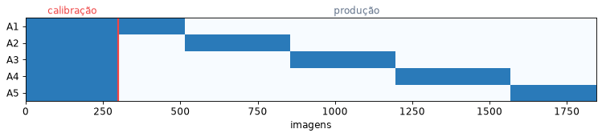

- **Calibração**: 300 imagens vistas pelos cinco anotadores. Permite comparar as pessoas entre si.
- **Produção**: as outras 1545 imagens, cada uma vista por **uma única pessoa**.

# Concordância entre anotadores

## Concordância bruta

- Fração dos itens em que dois anotadores deram o mesmo rótulo.
- Exemplo: dois inspetores classificam 100 peças.

|  | B: normal | B: defeito |
| --- | --- | --- |
| **A: normal** | 82 | 8 |
| **A: defeito** | 8 | 2 |

- Concordância bruta: $(82 + 2) / 100 = 0{,}84$. Parece alta.
- Mas cada um diz `normal` em 90% das peças. Respondendo **ao acaso** com essa frequência, eles concordariam em $0{,}9 \times 0{,}9 + 0{,}1 \times 0{,}1 = 0{,}82$.

## κ de Cohen

- Desconta da concordância observada $p_o$ a concordância esperada por acaso $p_e$:

$$\kappa = \frac{p_o - p_e}{1 - p_e}$$

- No exemplo anterior: $\kappa = (0{,}84 - 0{,}82) / (1 - 0{,}82) = 0{,}11$.
- $\kappa = 1$ é concordância perfeita, $\kappa = 0$ é o que o acaso produziria.
- $p_e$ é calculado a partir da frequência com que **cada anotador** usa cada classe.

## Como interpretar o valor

| κ | interpretação usual |
| --- | --- |
| abaixo de 0,20 | fraca |
| 0,21 a 0,40 | razoável |
| 0,41 a 0,60 | moderada |
| 0,61 a 0,80 | substancial |
| acima de 0,80 | quase perfeita |

- Essas faixas são uma **convenção**, e não um critério estatístico.
- O valor aceitável depende da tarefa. Em diagnóstico médico costuma-se exigir mais do que em classificação de sentimentos.
- É mais útil comparar valores de κ **dentro do mesmo projeto** (entre pares de pessoas, entre classes, antes e depois de revisar as instruções).

## κ de Fleiss

- O κ de Cohen compara **dois** anotadores. Com cinco anotadores há 10 pares, e cada par tem o seu κ de Cohen.
- O κ de Fleiss resume a concordância do **grupo inteiro** em um único valor.
- A fórmula é a mesma:

$$\kappa = \frac{p_o - p_e}{1 - p_e}$$

- O que muda é a forma de calcular $p_o$ e $p_e$.

## Exemplo de anotação

- Cinco anotadores classificam cinco imagens em três classes. Cada célula conta quantos anotadores escolheram aquela classe.

| imagem | `coffee mug` | `cup` | `pitcher` |
| --- | --- | --- | --- |
| 1 | 5 | 0 | 0 |
| 2 | 4 | 1 | 0 |
| 3 | 2 | 3 | 0 |
| 4 | 0 | 0 | 5 |
| 5 | 1 | 2 | 2 |

## Concordância dentro de uma imagem

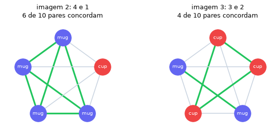

- Com 5 anotadores existem $5 \times 4 / 2 = 10$ pares possíveis.
- Uma classe com $n$ votos forma $n(n-1)/2$ pares que concordam.

## Concordância observada $p_o$

| imagem | votos | pares que concordam | fração |
| --- | --- | --- | --- |
| 1 | 5 | 10 | 1,0 |
| 2 | 4 e 1 | 6 + 0 = 6 | 0,6 |
| 3 | 2 e 3 | 1 + 3 = 4 | 0,4 |
| 4 | 5 | 10 | 1,0 |
| 5 | 1, 2 e 2 | 0 + 1 + 1 = 2 | 0,2 |

- $p_o$ é a média das frações: $(1{,}0 + 0{,}6 + 0{,}4 + 1{,}0 + 0{,}2) / 5 = 0{,}64$.
- Os anotadores concordam em 64% das vezes.

## Concordância esperada $p_e$

- Frequência de cada classe considerando todos os 25 votos:

|  | `coffee mug` | `cup` | `pitcher` |
| --- | --- | --- | --- |
| votos | 12 | 6 | 7 |
| frequência | 12/25 = 0,48 | 6/25 = 0,24 | 7/25 = 0,28 |

- Dois anotadores votando **ao acaso** com essas frequências escolhem ambos `coffee mug` com probabilidade $0{,}48^2$, e assim por diante:

$$p_e = 0{,}48^2 + 0{,}24^2 + 0{,}28^2 = 0{,}37$$

## Resultado do exemplo

$$\kappa = \frac{p_o - p_e}{1 - p_e} = \frac{0{,}64 - 0{,}37}{1 - 0{,}37} = 0{,}43$$

- Os anotadores concordam mais do que o acaso explicaria, mas a concordância é apenas moderada.

## κ por classe

- É possível calcular o κ de Fleiss **para cada classe**
- Para uma classe, cada voto vira “é a classe” ou “não é a classe”, e o mesmo cálculo é aplicado.
- Exemplo para o dataset `pvd_images`:

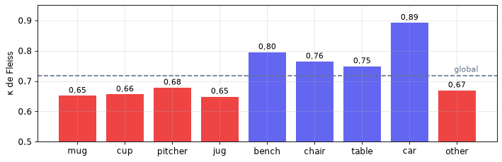

## Cuidados com o κ

- **Concordância não é acerto.** Cinco pessoas com o mesmo entendimento errado de uma classe têm κ alto.
- É sensível à **prevalência**: com uma classe muito dominante, $p_e$ fica alto e o κ cai mesmo com poucos desacordos.
- O κ de Fleiss exige o mesmo número de anotadores em todos os itens.

# Viés de anotadores

## Erro aleatório e erro sistemático

- **Erro aleatório**: distração, clique errado. Espalha-se por todas as classes e tende a ser cancelado quando há mais de um anotador.
- **Erro sistemático (viés)**: a pessoa erra **sempre na mesma direção**.

## Matriz de confusão por anotador

- Caso alguns rótulos de imagens sejam conhecidos, é possível construir a matriz de confusão de cada anotador:

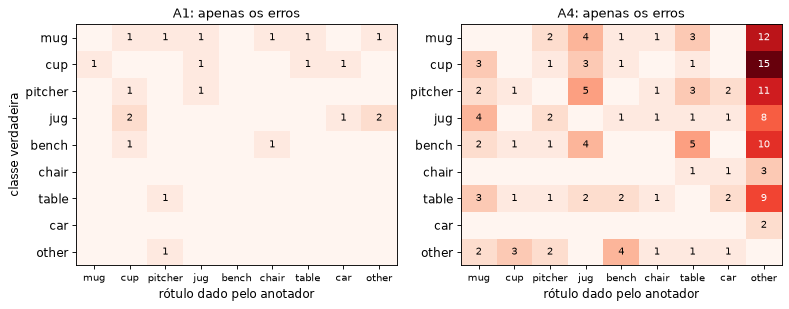

- `A1` erra pouco e sem direção preferida. `A4` na dúvida, anota como `other`.

# Resolução de conflitos

## Votação por maioria

- Na votação por maioria, cada imagem recebe o rótulo mais votado.
- Funciona quando os erros são **independentes**: dificilmente três pessoas erram a mesma imagem para a mesma classe.

## Quando a votação por maioria falha

- **Empates**: em situações com votos como 2, 2 e 1.
- **Viés compartilhado**: se a maior parte do time entende uma classe da mesma forma errada, a maioria reproduz o erro.
- **Anotadores de qualidade muito diferente**: o voto de um especialista vale o mesmo que o de um iniciante.
- Quando o problema é ambíguo de fato, a maioria esconde a ambiguidade. Um voto de 3 a 2 e um de 5 a 0 viram o mesmo rótulo. É interessante guardar a **fração de concordância** junto com o rótulo.

## Revisão por especialista

- Os itens em conflito são enviados a uma pessoa mais experiente, que decide o rótulo.
- O especialista é caro e lento, então ele vê **apenas os conflitos**, e não a fila inteira.
- Na prática os dois são combinados: maioria onde há consenso claro, especialista no restante.

# Confident learning

## A ideia

- Se um conjunto possui uma pequena parcela de rótulos errados, a maior parte dos exemplos de cada classe está correta. Um classificador treinado nesses dados aprende o **padrão majoritário** de cada classe.
- Quando esse classificador afirma **com confiança** que uma imagem rotulada como classe A na verdade é da classe B, há duas explicações: o modelo errou, ou o **rótulo** está errado.
- *Confident learning* é o procedimento que transforma essas discordâncias numa lista de rótulos suspeitos.

## Primeiro passo: Predições *out-of-fold*

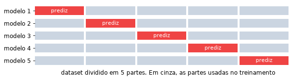

- Os dados são divididos em k partes. Cada parte é usada como teste de um modelo treinado nas outras k-1 partes.
- O resultado é uma matriz de probabilidades: uma linha por imagem, uma coluna por classe.

## Segundo passo: Definir um limiar por classe

- O limiar de cada classe é a **confiança média** do modelo nos exemplos rotulados com ela.
- O limiar é calculado como a **média** da coluna $k$ da matriz de probabilidades out-of-fold, calculada só nas linhas das imagens cujo rótulo de consenso é $k$.

## Exemplo no `pvd_images`

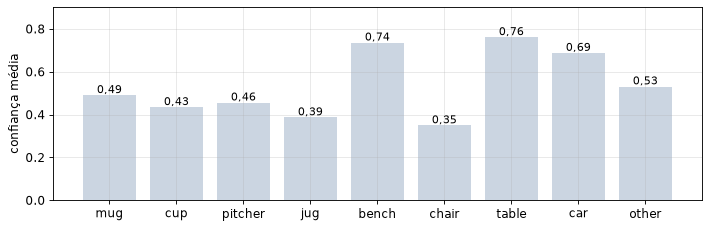

- Uma imagem é **suspeita** quando o modelo prefere outra classe, com probabilidade acima do limiar **dessa outra classe**.

## Discordâncias entre modelo e rótulo

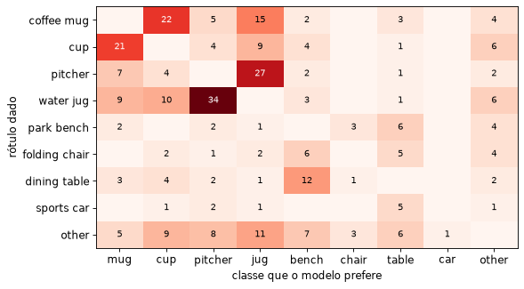

- O confident learning revela a **estrutura** do ruído: `pitcher` com `water jug`, `coffee mug` com `cup`.

# Ranqueamento e reanotação

## Margem do rótulo

- Dizer “suspeito ou não” é pouco quando o orçamento de revisão é limitado. É interessante **ordenar** a fila de anotação.
- Para cada imagem, a **margem** compara a probabilidade do rótulo dado com a da melhor alternativa:

$$\text{margem} = p(\text{rótulo dado}) - \max_{k \neq \text{dado}} p(k)$$

| margem | leitura | ação |
| --- | --- | --- |
| perto de $-1$ | o modelo tem certeza de outra classe | revisar primeiro |
| perto de $0$ | o modelo está dividido entre duas classes | imagem ambígua, pedir mais anotadores |
| perto de $+1$ | o modelo concorda com o rótulo | baixa prioridade |

## Revisar em ordem de margem

- Comparação entre análise de imagens aleatórias e por margem no `pvd_images`:

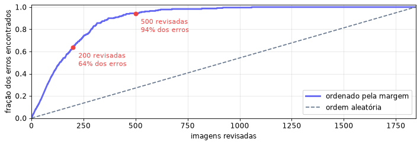

- Revisar pouco mais de um quarto do dataset encontra quase todos os erros.

## O que fazer com os suspeitos

- **Reanotar**: enviar a imagem para outra pessoa, sem mostrar o rótulo antigo nem a sugestão do modelo.
- **Remover**: aceitável quando há dados de sobra, mas tende a remover os exemplos difíceis.
- Muitos suspeitos no mesmo par de classes indicam um problema no **protocolo**.

## Roteiro de anotação e auditoria

1. Escrever o protocolo, com exemplos, contraexemplos e uma classe de escape.
2. Fazer uma rodada de calibração em que todos anotam as mesmas imagens.
3. Medir o κ entre pares de anotadores e por classe. Revisar as instruções onde ele for baixo.
4. Olhar a matriz de confusão e o tempo de cada anotador antes de distribuir a produção.
5. Na produção, manter alguma redundância e guardar as anotações individuais, não só o consenso.
6. Resolver conflitos por maioria, e enviar empates e casos recorrentes ao especialista.
7. Treinar um classificador simples, obter predições *out-of-fold* e ordenar as imagens pela margem.
8. Reanotar o topo da fila, até onde o orçamento permitir.

## Assuntos adicionais

- O **α de Krippendorff** é uma medida de concordância que aceita itens com número diferente de anotadores e rótulos ordinais ou numéricos.
- A biblioteca `cleanlab` implementa o *confident learning* completo, incluindo a estimativa da matriz conjunta entre rótulo dado e rótulo verdadeiro.
- *Active learning* usa a mesma ideia de margem para escolher quais imagens **ainda sem rótulo** vale a pena anotar.